# Practicum1

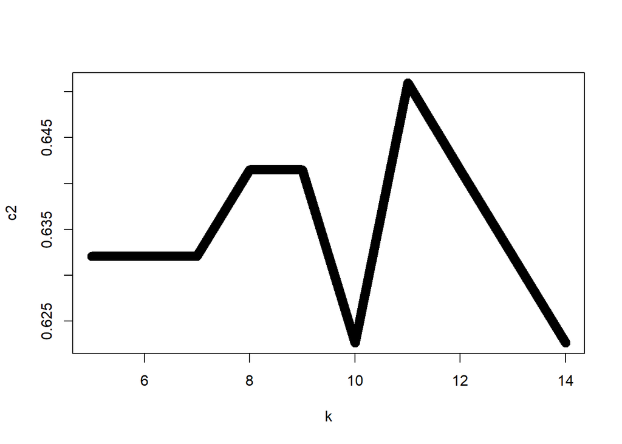

```r
plot(k,c2,type='l',lwd=10)
```

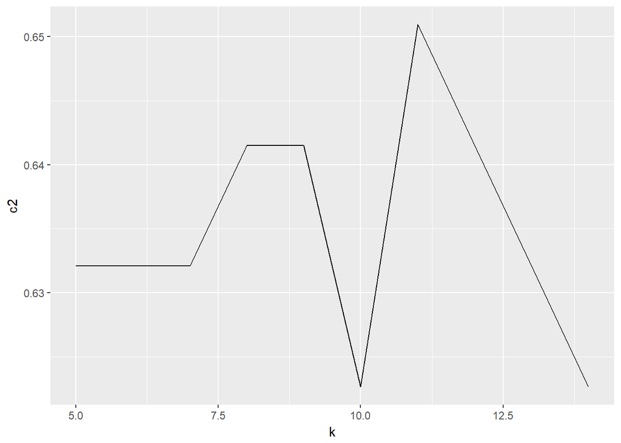

```r
library(ggplot2)
ggplot(NULL,aes(k,c2)) + geom_line()
```

Q-12 Produce a cross-table confusion matrix showing the accuracy of the classification using a package of your choice and a k of your choice.

```r
library(gmodels)
model_prediction <- knn(train = glass_training_final[,1:9], test = glass_validation_final[,1:9],cl=glass_training_final[,10],k=11)
model_prediction
```

```
##   [1] 1 2 1 2 1 2 2 7 2 2 1 6 1 2 2 1 3 1 1 2 1 2 2 2 6 1 2 7 7 2 2 2 1 2 1
##  [36] 6 2 2 1 6 1 1 6 1 2 1 2 1 1 2 6 1 7 2 7 2 7 6 7 7 1 2 7 1 1 3 7 7 1 1
##  [71] 2 1 2 2 1 2 2 7 1 2 6 2 2 2 1 1 1 2 1 2 2 1 2 1 2 2 1 1 2 2 1 1 2 2 7
## [106] 6
## Levels: 1 2 3 5 6 7
```

```r
CrossTable(x=glass_validation_final[,10],y=model_prediction,prop.chisq=FALSE)
```

```
##
##
##    Cell Contents
## |-------------------------|
## |                       N |
## |           N / Row Total |
## |           N / Col Total |
## |         N / Table Total |
## |-------------------------|
##
##
## Total Observations in Table:  106
##
##
##                              | model_prediction
## glass_validation_final[, 10] |         1 |         2 |         3 |         6 |         7 | Row Total |
## -----------------------------|-----------|-----------|-----------|-----------|-----------|-----------|
##                            1 |        26 |         9 |         1 |         0 |         0 |        36 |
##                              |     0.722 |     0.250 |     0.028 |     0.000 |     0.000 |     0.340 |
##                              |     0.684 |     0.205 |     0.500 |     0.000 |     0.000 |           |
##                              |     0.245 |     0.085 |     0.009 |     0.000 |     0.000 |           |
## -----------------------------|-----------|-----------|-----------|-----------|-----------|-----------|
##                            2 |         7 |        27 |         0 |         3 |         0 |        37 |
##                              |     0.189 |     0.730 |     0.000 |     0.081 |     0.000 |     0.349 |
##                              |     0.184 |     0.614 |     0.000 |     0.333 |     0.000 |           |
##                              |     0.066 |     0.255 |     0.000 |     0.028 |     0.000 |           |
## -----------------------------|-----------|-----------|-----------|-----------|-----------|-----------|
##                            3 |         4 |         3 |         1 |         0 |         0 |         8 |
##                              |     0.500 |     0.375 |     0.125 |     0.000 |     0.000 |     0.075 |
##                              |     0.105 |     0.068 |     0.500 |     0.000 |     0.000 |           |
##                              |     0.038 |     0.028 |     0.009 |     0.000 |     0.000 |           |
## -----------------------------|-----------|-----------|-----------|-----------|-----------|-----------|
##                            5 |         0 |         2 |         0 |         5 |         1 |         8 |
##                              |     0.000 |     0.250 |     0.000 |     0.625 |     0.125 |     0.075 |
##                              |     0.000 |     0.045 |     0.000 |     0.556 |     0.077 |           |
##                              |     0.000 |     0.019 |     0.000 |     0.047 |     0.009 |           |
## -----------------------------|-----------|-----------|-----------|-----------|-----------|-----------|
##                            6 |         0 |         0 |         0 |         1 |         0 |         1 |
##                              |     0.000 |     0.000 |     0.000 |     1.000 |     0.000 |     0.009 |
##                              |     0.000 |     0.000 |     0.000 |     0.111 |     0.000 |           |
##                              |     0.000 |     0.000 |     0.000 |     0.009 |     0.000 |           |
## -----------------------------|-----------|-----------|-----------|-----------|-----------|-----------|
##                            7 |         1 |         3 |         0 |         0 |        12 |        16 |
##                              |     0.062 |     0.188 |     0.000 |     0.000 |     0.750 |     0.151 |
##                              |     0.026 |     0.068 |     0.000 |     0.000 |     0.923 |           |
##                              |     0.009 |     0.028 |     0.000 |     0.000 |     0.113 |           |
## -----------------------------|-----------|-----------|-----------|-----------|-----------|-----------|
##                 Column Total |        38 |        44 |         2 |         9 |        13 |       106 |
##                              |     0.358 |     0.415 |     0.019 |     0.085 |     0.123 |           |
## -----------------------------|-----------|-----------|-----------|-----------|-----------|-----------|
##
##
```

Q-13 Comment on the run-time complexity of the k-NN for classifying w new cases using a training data set of n cases having m features. Assume that m is “large”. How does this algorithm behave as w, n, and m increase? Would this algorithm be “fast” if the training data set and the number of features are large?